# Marine Habitat Classification Using Deep Learning - Classifying VME Indicators in Underwater Images

**📚 Reading Time:** 20-25 minutes  
**🛠️ Skills Required:** Basic Machine Learning Tools in Python, familiarity with neural networks concepts  
**🎯 Difficulty:** Intermediate

## Abstract

This tutorial demonstrates how to build a deep learning pipeline for classifying Marine Organisms indicative of Vulnerable Marine Ecosystems (VMEs). Using transfer learning with PyTorch, we develop a ResNet-based model to identify identify corals, sponges, crinoids, and fish from FathomNet data. We address the unique challenges of underwater imagery classification through data preprocessing, model training, and hyperparameter optimisation. Our model achieves 41% overall accuracy, with performance varying significantly across taxa (9.8%-62.6%). The techniques presented address the unique challenges of underwater imagery classification while providing insights into marine habitat assessment.

## Learning Objectives

By the end of this tutorial, you will be able to:

- Preprocess underwater imagery data for deep learning, which includes handling class imbalances and image quality issues
- Implement transfer learning using ResNet architecture in PyTorch for Marine Classification
- Visualise model attention using Grad-CAM to interpret the model's classification decision
- Analyse Confusion Matrices to identify and address misclassification
- Visualise model attention using Grad-CAM for interpretability
- Optimise hyperparameters to improve model performance for underwater imagery classification
- Evaluate strengths and limitations of deep learning approaches for Marine Habitat Assessment

#### 1. Introduction

- What are VMEs?
- Why Deep Learning for Marine Imagery?
- Comparison with Existing Approaches

#### 2. Understanding Marine Imagery Data

- FathomNet: A Specialised Marine Database
- Why FathomNet?
- Vulnerable Marine Ecosystem (VME) Indicators

#### 3. Data Collection and Construction

- Data Collection with FathomNet API
- Dataset Exploration and Visualisation
- Observed Challenges in Deep Sea Imagery
- Object Classification
- Dataset Splitting Strategy
- Data Preprocessing
- Creating the Dataset Class

#### 4. Transfer Learning for Marine Classification

- Introduction to Transfer Learning
- ResNet Architecture
- Model Adaptation for VME Detection

#### 5. Model Training and Evaluation

- Training Process
- Training Loop
- Training Results Analysis

#### 6. Hyperparameter Tuning and Optimisation

- Impact of Different Hyperparameters
- Analysis of Fine-tuning Results
- Model Prediction Visualisation
- Confusion Matrix Analysis
- Confusion Pattern Analysis
- Overall Class Performance Analysis
- Analysing Grad-CAM Visualisations

#### 7. Results, Discussion, and Limitations

- Interpreting Results for Marine Conservation
- Limitations
- Future Improvements

#### 8. Conclusion

- Conclusion

#### 9. References

- References

## 1. Introduction

### 1.1 What are VMEs?

The deep ocean remains one of Earth's least explored environments. Beyond its mysteries lie crucial ecosystems that support marine biodiversity, regulate climate, and provide ecosystem services. Among these, Vulnerable Marine Ecosystems (VMEs) are particularly important yet increasingly threatened by human activities like bottom trawling, deep-sea mining, and climate change.

**❓ What are VMEs?**  
Vulnerable Marine Ecosystems are deep-sea habitats characterised by unique communities of organisms that are particularly susceptible to disturbance. They are identified by the presence of indicator species like cold-water corals, sponges, and certain echinoderms.

### 1.2 Why Deep Learning for Marine Imagery?

Traditional marine habitat assessment relies on manual review of underwater imagery - a time-consuming process that creates bottlenecks in research. With thousands of hours of video collected annually, marine scientists need automated tools to efficiently process this data.

Traditional marine habitat assessment done around the world often require manual review of underwater imagery captured by machines - a time-consuming process that is plaguing the deep sea community. The ability to collect seafloor imagery has largely outpaced the capacity to analyse it [(Price et al., 2025)](https://www.nature.com/articles/s41597-025-04491-1), and therefore hindering the mobilisation of crucial environmental information.

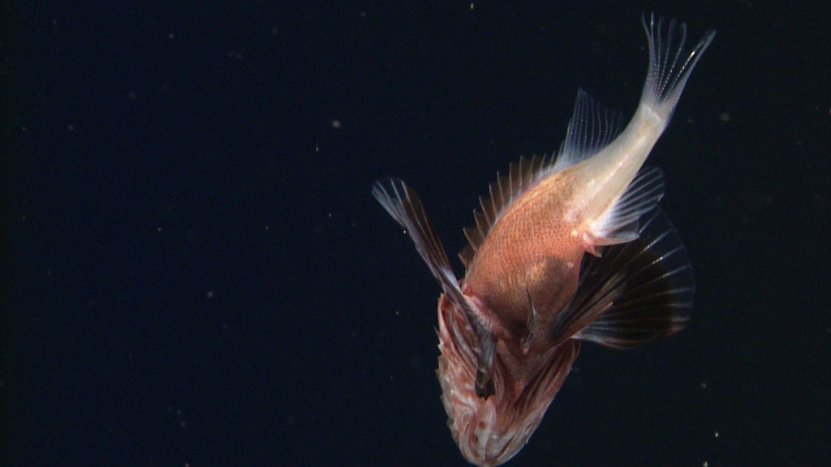

```python
from IPython.display import Image, display
display(Image(filename='vme_dataset/fish/4bd7e47f-5c2f-45b9-a868-1dcecfa6df8b.png', width=600))
```

### 1.3 Comparison with Existing Approaches

While several tutorials exist for general image classification, few address the specific needs of marine imagery analysis:

## Comparison with Existing Approaches

| Tutorial/Model | Focus | Pros | Cons |
| --- | --- | --- | --- |
| MBARI FathomNet VME Detector | VME indicator detection | Object detection (not just classification), High mAP (0.713), Deployed research model | Complex YOLOv8 architecture, Requires more computational resources, Not tutorial-focused |
| **This Tutorial** | VME indicator classification | Step-by-step learning approach, Uses open data (FathomNet), Includes interpretability (Grad-CAM), Focus on transfer learning principles | Limited dataset sise, Lower accuracy than specialised research models, Classification only (no localisation) |

Our approach differs by:

1. Focus on classification rather than object detection
2. Addressing class imbalance common in marine data
3. Applying Grad-CAM for biological interpretability
4. Optimising specifically for underwater imagery challenges

Firstly, lets begin by understanding our Dataset

## 2. Understanding Marine Imagery Data

In this section, we'll explore our dataset of underwater imagery used to identify VME indicators. Understanding that marine imagery presents unique challenges that differ from typical computer vision datasets.

### 2.1 FathomNet: A Specialised Marine Imagery Database

[FathomNet](https://fathomnet.org) is an open-source database of underwater imagery designed specifically for machine learning applications in marine science. Unlike general image databases like ImageNet, FathomNet provides expert-annotated imagery of marine organisms with taxonomic precision ([Katija et al., 2022](https://www.nature.com/articles/s41598-022-19939-2)). Below is a table of information which a glimpse into Fathomnet Dataset

```python
from IPython.display import Markdown, display, HTML
import pandas as pd

fathomnet_info = {
    "Images": "~800,000",
    "Annotations": "~1.8 million",
    "Taxa": "~2,000 unique taxa",
    "Sources": "MBARI, NOAA, OET, multiple research institutions",
    "Annotation Type": "Expert-validated bounding boxes",
    "Website": "https://fathomnet.org"
}

df = pd.DataFrame(list(fathomnet_info.items()), columns=["Attribute", "Value"])
display(df.style.set_properties(**{'text-align': 'left'})
          .set_caption("FathomNet Database Overview"))
```

FathomNet Database Overview

|  | Attribute | Value |
| --- | --- | --- |
| 0 | Images | ~800,000 |
| 1 | Annotations | ~1.8 million |
| 2 | Taxa | ~2,000 unique taxa |
| 3 | Sources | MBARI, NOAA, OET, multiple research institutions |
| 4 | Annotation Type | Expert-validated bounding boxes |
| 5 | Website | https://fathomnet.org |

### 2.2 Why FathomNet ?

- (Mostly) Taxonomically accurate annotations by marine biology experts
- Consistent methodology for annotation across varied marine environments
- Detailed metadata including location, depth, and collection methodology
- Focus on marine species relevant to ecological assessment
- Open Access, as an open source database, FathomNet enables reproducible research and widespread adaption within the Marine Science Community
- The dataset is largely supported by Major marine research institutions, which ensure ongoing maintenance.

### 2.3 Vulnerable Marine Ecosystem (VME) Indicators

For our classifier, we focus on four key categories of marine organisms that serve as indicators of Vulnerable Marine Ecosystems (VMEs). These organisms are [recognised by the Food and Agriculture Organisation (FAO)](https://www.fao.org/in-action/vulnerable-marine-ecosystems/vme-indicators/en/) as signaling the presence of ecosystems that may require conservation attention.

| Category | Scientific Examples | Common Names | Importance |
| --- | --- | --- | --- |
| coral | Antipatharia, Paragorgia, Primnoa, Pennatulacea, Lophelia | Black corals, Bubblegum corals, Sea pens, Cold-water corals | Create 3D habitat structure, slow-growing, extremely vulnerable to physical damage |
| sponge | Porifera, Hexactinellida, Demospongiae | Glass sponges, Barrel sponges, Demosponges | Filter water, provide habitat complexity, contain bioactive compounds |
| crinoid | Crinoidea, Feather star | Feather stars, Sea lilies | Indicators of healthy benthic ecosystems, filter feeders |
| fish | Sebastes, Macrouridae | Rockfish, Grenadiers | Higher trophic levels, often endemic to specific deep-sea features |

```python
# Set up VME indicator categories
vme_categories = {
    "coral": ["Antipatharia", "Paragorgia", "Primnoa", "Pennatulacea", "Lophelia"],
    "sponge": ["Porifera", "Hexactinellida", "Demospongiae"],
    "crinoid": ["Crinoidea", "Feather star"],
    "fish": ["Sebastes", "Macrouridae"]
}
```

## 3. Data Collection and Construction

### 3.1 Data Collection with Fathomnet API

As the person following the tutorial, you are able to download the data yourself by using an [API provided by fathonment](https://fathomnet-py.readthedocs.io/en/latest/api.html#module-fathomnet.api.xapikey). In order to build our datase, we use the [FathomNet Python API](https://fathomnet-py.readthedocs.io/en/latest/api.html#module-fathomnet.api.xapikey) to query and download relevant imagery. The code below demostrates how we access the database and structure our queries

```python
import os
import random
from urllib.request import urlretrieve
from fathomnet.api import images, boundingboxes
import json


# Create a base directory for all VME data
base_dir = "vme_dataset"
os.makedirs(base_dir, exist_ok=True)

# Function to download an image
def download_image(image_record, target_dir):
    url = image_record.url  # Extract the URL
    extension = os.path.splitext(url)[-1]
    image_filename = os.path.join(target_dir, image_record.uuid + extension)
    try:
        urlretrieve(url, image_filename)
        return image_filename
    except Exception as e:
        print(f"Error downloading {url}: {e}")
        return None
```

The above code will retrieve images from the Fathomnet API directly, making it easier to construct a specialised dataset for our purpose

Here, we build our dataset by creating a subset of Fathomnet Dataset, by selecting only the Taxa that we are interested in, which is from the VME Categories (the organism that indicate a VME).

Each sample we download from the fathomnet dataset contains objects detected within that image, here we build a dataset with images properly categorised and annotated with bounding box information for the marine organism of interest.

We will be downloading only taxas that are VMEs, although there are 100s if not thousands more taxa that are VME indicators, we will be keeping it simple by only using the organisms listed in our table. Below, we keep a record of the annotation and the image downlaoded.

```python
def write_annotation(image_record, image_filename, category):
    annotation = {
        "filename": os.path.basename(image_filename),
        "width": image_record.width,
        "height": image_record.height,
        "objects": []
    }

    for box in image_record.boundingBoxes:
        annotation["objects"].append({
            "category": category,
            "bbox": [box.x, box.y, box.width, box.height]
        })

    json_filename = os.path.splitext(image_filename)[0] + '.json'
    with open(json_filename, 'w') as f:
        json.dump(annotation, f)

    return json_filename


stats = {category: 0 for category in vme_categories.keys()}

for category, concepts in vme_categories.items():
    # Create a directory for this category
    category_dir = os.path.join(base_dir, category)
    os.makedirs(category_dir, exist_ok=True)

    max_images_per_category = 100
    current_image_count = 0

    for concept in concepts:
        print(f"Processing {concept} (category: {category})")

        # Get images for this concept
        concept_images = images.find_by_concept(concept)
        print(f"Found {len(concept_images)} images for {concept}")

        # Randomly shuffle to get a variety
        random.shuffle(concept_images)

        for image_record in concept_images:
            if current_image_count >= max_images_per_category:
                break

            # Download the image
            image_filename = download_image(image_record, category_dir)
            if not image_filename:
                continue

            # Generate annotation
            try:
                write_annotation(image_record, image_filename, category)
                current_image_count += 1
                stats[category] += 1

                if current_image_count % 10 == 0:
                    print(f"Downloaded {current_image_count} images for {category}")
            except Exception as e:
                print(f"Error annotating {image_filename}: {e}")

    print(f"Completed {category}: {stats[category]} images")

print("\nDataset collection complete!")
print("Images per category:")
for category, count in stats.items():
    print(f"  {category}: {count}")
print(f"Total: {sum(stats.values())} images")
```

Below are some examples of the samples from the dataset, as you can see the bounding box highlighting four key organisms : corals (red), sponges (blue), crinoids (green), and fish (orange). The code below, selects random samples from our Subset of FathomNet and displays them with their corresponding annotations. This is inorder to undderstand how the data looks like. These samples illustrate several important characteristics of underwater imagery from FathomNet:

### 3.2 Dataset Exploration and Visualisation

```python
import matplotlib.pyplot as plt
import matplotlib.patches as patches
import numpy as np
import random
import json
import os
from PIL import Image

def visualise_dataset_samples(dataset_dir, num_samples=3):
    categories = ["coral", "sponge", "crinoid", "fish"]
    category_colors = {
        "coral": "red",
        "sponge": "blue",
        "crinoid": "green",
        "fish": "orange"
    }

    fig, axes = plt.subplots(len(categories), num_samples, figsize=(15, 12))
    fig.suptitle('VME Dataset Samples with Bounding Boxes', fontsize=16)

    for row, category in enumerate(categories):
        # Get all image files for this category
        category_dir = os.path.join(dataset_dir, category)
        image_files = [f for f in os.listdir(category_dir)
                      if f.endswith(('.png', '.jpg', '.jpeg'))]

        # Select random samples
        if len(image_files) > num_samples:
            samples = random.sample(image_files, num_samples)
        else:
            samples = image_files

        # Plot each sample
        for col, img_file in enumerate(samples):
            if col >= num_samples:
                break

            # Load image
            img_path = os.path.join(category_dir, img_file)
            img = Image.open(img_path).convert("RGB")

            # Load annotation
            json_file = os.path.splitext(img_file)[0] + '.json'
            json_path = os.path.join(category_dir, json_file)

            with open(json_path, 'r') as f:
                annotation = json.load(f)

            # Display image
            axes[row, col].imshow(img)
            axes[row, col].set_title(f"{category}", fontsize=10)

            # Add bounding boxes
            for obj in annotation["objects"]:
                x, y, width, height = obj["bbox"]

                # Create rectangle patch
                rect = patches.Rectangle(
                    (x, y), width, height,
                    linewidth=2,
                    edgecolor=category_colors[category],
                    facecolor="none"
                )

                axes[row, col].add_patch(rect)

            axes[row, col].set_xticks([])
            axes[row, col].set_yticks([])

    plt.tight_layout(rect=[0, 0, 1, 0.95])
    plt.savefig("vme_dataset_samples.png", dpi=300, bbox_inches="tight")
    plt.show()

    print("Dataset visualisation saved as 'vme_dataset_samples.png'")


def visualise_single_sample(image_path, json_path=None):
    if json_path is None:
        json_path = os.path.splitext(image_path)[0] + '.json'

    img = Image.open(image_path).convert("RGB")

    # Load annotation
    with open(json_path, 'r') as f:
        annotation = json.load(f)

    fig, ax = plt.subplots(1, figsize=(10, 8))
    ax.imshow(img)

    filename = os.path.basename(image_path)
    width, height = img.size

    ax.set_title(f"File: {filename} | Dimensions: {width}x{height}", fontsize=12)

    # Add bounding boxes
    for i, obj in enumerate(annotation["objects"]):
        x, y, width, height = obj["bbox"]
        category = obj["category"]

        colors = {
            "coral": "red",
            "sponge": "blue",
            "crinoid": "green",
            "fish": "orange"
        }
        color = colors.get(category, "purple")

        rect = patches.Rectangle(
            (x, y), width, height,
            linewidth=2,
            edgecolor=color,
            facecolor="none"
        )

        ax.add_patch(rect)

        ax.text(
            x, y-5,
            f"{category} ({i+1})",
            color="white",
            fontsize=10,
            bbox=dict(facecolor=color, alpha=0.8, pad=1)
        )

    # Remove axis ticks
    ax.set_xticks([])
    ax.set_yticks([])

    plt.tight_layout()
    plt.savefig("detailed_annotation.png", dpi=300, bbox_inches="tight")
    plt.show()
```

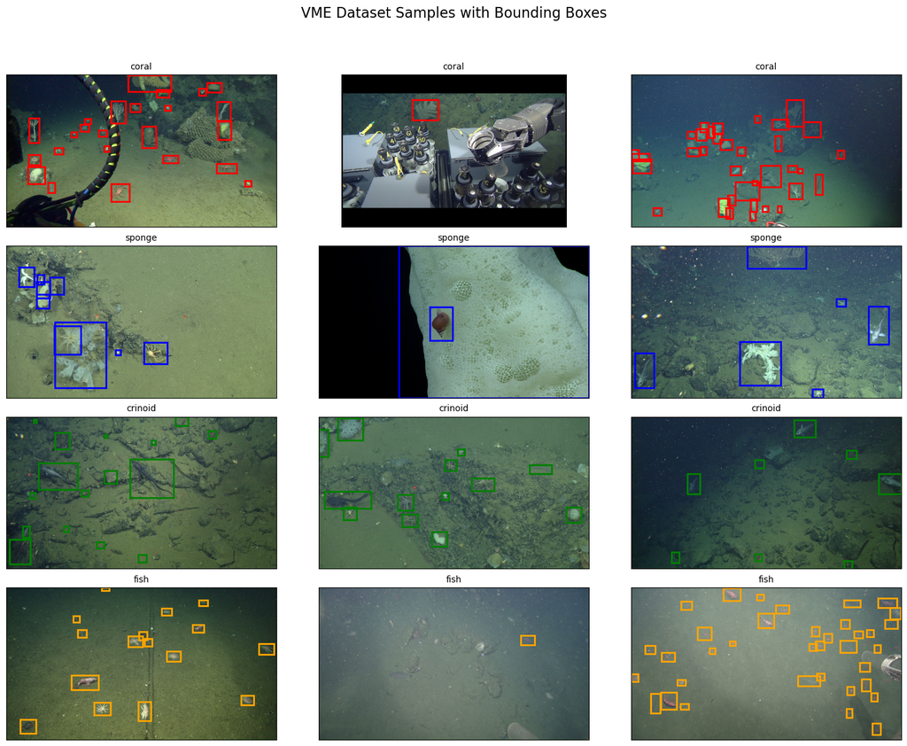

```
Dataset visualization saved as 'vme_dataset_samples.png'
```

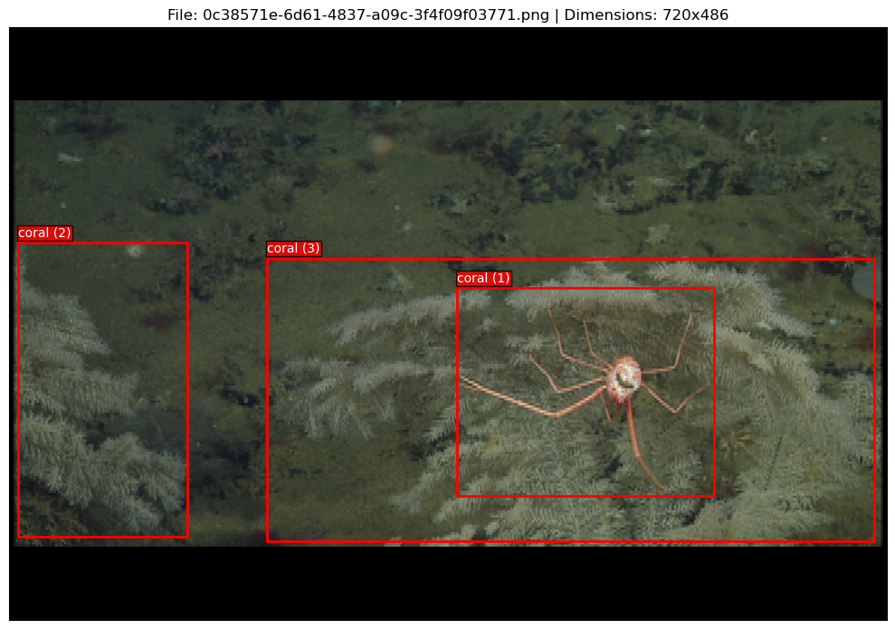

[output not shown]

```python
visualise_dataset_samples("vme_dataset")

coral_image_path = "vme_dataset/coral/0c38571e-6d61-4837-a09c-3f4f09f03771.png"
visualise_single_sample(coral_image_path)
```

### 3.3 Observed Challenges in Deep Sea Imagery

As you can observe from the samples, the figure above shows a sea spider incorrectly labelled as a Coral. This is a challenge observed with working with Deep Sea imagery, often times they are labelled by [a trained operator](https://www.nature.com/articles/s41597-025-04491-1) which causes discrepancies in the labelling of data.

Based on our sample images, we can identify several specific challenges:

| Challenge | Description | Evidence in Sample Images |
| --- | --- | --- |
| Low Visibility | Limited light penetration and particulate matter create low contrast | Murky water conditions in both images, making object boundaries difficult to distinguish |
| Variable Lighting | Different ROV lighting equipment and depths create inconsistent illumination | Noticeable differences in lighting quality between Image 1 and the samples in Image 2 |
| Perspective Variation | Organisms photographed from different angles and distances | Coral and sponge specimens appear from various viewpoints across the dataset |
| Similar Morphology | Different taxa may have similar appearance (convergent evolution) | Branching structures in corals could be confused with certain sponge morphologies |
| Image Quality | ROV cameras vary in resolution and quality | Variability in image clarity and definition across samples |
| Scale Issues | Difficult to determine size without reference objects | Inconsistent bounding box sizes without standardised scale references |
| Background Complexity | Seafloor substrates vary considerably between locations | Different textures and sediment types visible across images |

This tutorial aims to demostrate how to overcome some of these challenges by using transfer learning with RestNet architecture in PyTorch

#### How These Challenges Impact Our Approach:

- **Transfer Learning:** Limited data means we need to leverage pre-trained features
- **Cropping:** Focusing on the organism reduces background variability
- **Data Augmentation:** Helps model generalise despite lighting and perspective differences
- **Interpretability:** Using Grad-CAM to understand which features the model uses

### 3.4 Object Classification

For this tutorial, I have chosen to focus exclusively on **object classification** rather than full object detection, this is for several reasons :

- **Educational Focus**: For this tutorial, classification provides a clearer introduction to deep learning concepts without the added complexity of localisation.
- **Better Performance with Limited Data**: Deep sea imagery datasets are typically limited in size. Classification models generally require less training data to achieve good performance compared to detection models.
- **Dataset Characteristics**: As visible in the samples, many images contain multiple instances of the same class (particularly evident in the sponge and crinoid images). For VME identification purposes, detecting the presence of indicator species is often more important than precisely locating each instance.
- **Practical Implementation**: Using cropped regions based on the provided bounding boxes allows us to create a classification dataset that focuses directly on the organisms' features, reducing background variability.
- **Performance Consideration**: With our limited dataset size, classification models are likely to achieve better performance than more complex detection models that require larger training sets.

This focused approach allows us to build effective classification models while providing a solid foundation for more advanced computer vision techniques in marine image analysis.

### 3.5 Dataset Splitting Strategy

Our dataset is split into three parts:

1. **Training set (70%)**: Used to train the model and update weights.
2. **Validation set (15%)**: Used to tune hyperparameters and prevent overfitting. The model doesn't directly learn from this data, but we use performance on this set to guide model development.
3. **Test set (15%)**: Completely held out until final evaluation. This gives us an unbiased estimate of how the model will perform on unseen data.

We maintain the same distribution of classes across all three splits using stratified sampling to ensure each set has a balanced representation of all VME indicator categories.

```python
import os
import json
import random
import shutil
from sklearn.model_selection import train_test_split

os.makedirs("vme_dataset/train", exist_ok=True)
os.makedirs("vme_dataset/val", exist_ok=True)
os.makedirs("vme_dataset/test", exist_ok=True)

dataset = {}
for category in ["coral", "sponge", "crinoid", "fish"]:
    category_dir = os.path.join("vme_dataset", category)

    # Find all image files and their corresponding annotations
    image_files = [f for f in os.listdir(category_dir) if f.endswith(('.png', '.jpg', '.jpeg'))]
    data_pairs = []

    for img_file in image_files:
        json_file = os.path.splitext(img_file)[0] + '.json'
        img_path = os.path.join(category_dir, img_file)
        json_path = os.path.join(category_dir, json_file)

        if os.path.exists(json_path):
            data_pairs.append((img_path, json_path, category))

    dataset[category] = data_pairs

# Split data (70% train, 15% val, 15% test)
train_data = []
val_data = []
test_data = []

for category, pairs in dataset.items():
    train_pairs, temp_pairs = train_test_split(pairs, test_size=0.3, random_state=42)

    val_pairs, test_pairs = train_test_split(temp_pairs, test_size=0.5, random_state=42)

    train_data.extend(train_pairs)
    val_data.extend(val_pairs)
    test_data.extend(test_pairs)

splits = {
    "train": train_data,
    "val": val_data,
    "test": test_data
}

for split_name, split_data in splits.items():
    for img_path, json_path, category in split_data:
        img_filename = os.path.basename(img_path)
        json_filename = os.path.basename(json_path)

        dest_img_path = os.path.join("vme_dataset", split_name, f"{category}_{img_filename}")
        dest_json_path = os.path.join("vme_dataset", split_name, f"{category}_{json_filename}")

        shutil.copy(img_path, dest_img_path)
        shutil.copy(json_path, dest_json_path)

    manifest = {
        "data": [
            {
                "image": f"{category}_{os.path.basename(img_path)}",
                "annotation": f"{category}_{os.path.basename(json_path)}",
                "category": category
            }
            for img_path, json_path, category in split_data
        ]
    }

    with open(os.path.join("vme_dataset", f"{split_name}_manifest.json"), "w") as f:
        json.dump(manifest, f, indent=2)

print(f"Dataset split complete:")
print(f"  Training: {len(train_data)} images")
print(f"  Validation: {len(val_data)} images")
print(f"  Testing: {len(test_data)} images")
```

```
Dataset split complete:
  Training: 280 images
  Validation: 60 images
  Testing: 60 images
```

##### Here's the actual distribution of images across our splits which we can visualise using matplotlib

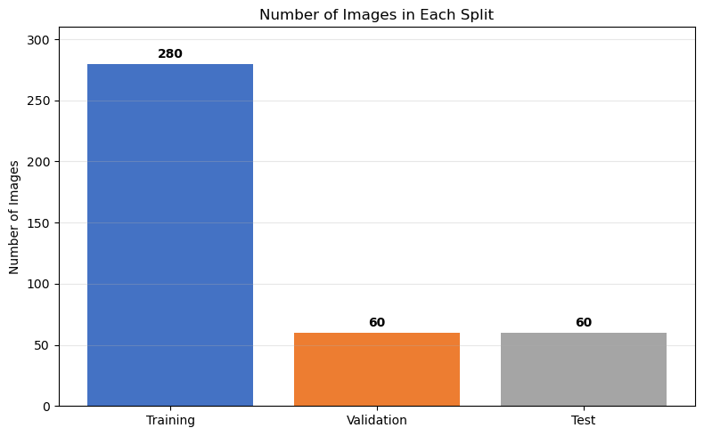

```python
import matplotlib.pyplot as plt
import numpy as np

train_count = 280  # 70% of 400
val_count = 60     # 15% of 400
test_count = 60    # 15% of 400

split_labels = ['Training', 'Validation', 'Test']
split_counts = [train_count, val_count, test_count]

plt.figure(figsize=(8, 5))
bars = plt.bar(split_labels, split_counts, color=['#4472C4', '#ED7D31', '#A5A5A5'])

for bar, count in zip(bars, split_counts):
    plt.text(bar.get_x() + bar.get_width()/2, bar.get_height() + 5,
            count, ha='center', fontweight='bold')

plt.title('Number of Images in Each Split')
plt.ylabel('Number of Images')
plt.ylim(0, train_count + 30)
plt.grid(axis='y', alpha=0.3)
plt.tight_layout()
plt.show()
```

Before we move on, we import necessary packages such as Torch, Torchvision, matplotlib, numpy for our training and evaluation later down the line

```python
import torch
import torch.nn as nn
import torch.optim as optim
import torchvision
import torchvision.transforms as transforms
from torchvision.models import resnet50, ResNet50_Weights
from torch.utils.data import Dataset, DataLoader
import matplotlib.pyplot as plt
import os
from PIL import Image
import json
import numpy as np
```

### 3.6 Data Preprocessing

Before feeding images to our model, we apply several preprocessing steps to normalise the data and prepare it for deep learning:

```python
import torchvision.transforms as transforms

# Define our preprocessing pipeline
preprocess = transforms.Compose([
    transforms.Resize((224, 224)),
    transforms.ToTensor(),
    transforms.Normalize(
        mean=[0.485, 0.456, 0.406],
        std=[0.229, 0.224, 0.225]
    )
])
```

#### 3.6.1 Preprocessing Steps

1. **Resize to 224×224**: Standard input size for ResNet models, providing consistent dimensions regardless of the original image aspect ratio.
2. **Convert to tensor**: Transform PIL Image to PyTorch tensor in the format expected by the model (C×H×W with values normalised to [0,1]).
3. **Normalise**: Scale values using ImageNet mean and standard deviation since we'll be using a pretrained model that was initially trained on that dataset.
4. **Cropping**: We extract just the region of interest using bounding box annotations to focus on the organism.

The cropping step is particularly important for our underwater imagery as it:

- Eliminates background variation (water, substrate, etc.)
- Focuses the model's attention on the organism's features
- Reduces the impact of variable camera distances and perspectives
- Creates consistency across different imaging platforms

### 3.7 Creating the Dataset class

To tie everything together, we implement a PyTorch Dataset class that handles loading, cropping and preprocessing our VME indicator images.

This dataset class:

- Loads images and annotations from their respective directories
- Extracts each object of interest using its bounding box
- Applies the preprocessing transformations
- Maps category names to numerical indices for training
- Handles potential errors gracefully to ensure training can continue

Now that we've prepared our data, we're ready to move on to building our deep learning model using transfer learning with ResNet. Remember, here we tranform the image so that our sample only contains one object. We process each image and save a cropped sample using the Dataset class below

```python
import torch
from torch.utils.data import Dataset, DataLoader
import torchvision.transforms as transforms
from PIL import Image
import os
import json

class VMECroppedClassificationDataset(Dataset):
    def __init__(self, root_dir, transform=None):
        self.root_dir = root_dir
        self.transform = transform or transforms.Compose([
            transforms.Resize((224, 224)),
            transforms.ToTensor(),
            transforms.Normalize([0.485, 0.456, 0.406], [0.229, 0.224, 0.225])
        ])

        # Create mapping of categories to numerical labels
        self.categories = ['coral', 'sponge', 'crinoid', 'fish']
        self.class_to_idx = {cls: i for i, cls in enumerate(self.categories)}

        self.samples = []

        for category in self.categories:
            category_dir = os.path.join(root_dir, category)
            if not os.path.exists(category_dir):
                continue

            for img_file in os.listdir(category_dir):
                if not img_file.endswith(('.jpg', '.png', '.jpeg')):
                    continue

                json_file = os.path.splitext(img_file)[0] + '.json'
                json_path = os.path.join(category_dir, json_file)

                if not os.path.exists(json_path):
                    continue

                # Load annotations
                with open(json_path, 'r') as f:
                    try:
                        annotation = json.load(f)
                    except json.JSONDecodeError:
                        continue

                img_path = os.path.join(category_dir, img_file)

                for obj in annotation.get('objects', []):
                    if 'bbox' in obj:
                        # Store image path, bbox, and label
                        self.samples.append((
                            img_path,
                            obj['bbox'],  # [x, y, width, height]
                            self.class_to_idx.get(category, 0)
                        ))

        print(f"Found {len(self.samples)} cropped samples across {len(self.categories)} categories")

    def __len__(self):
        return len(self.samples)

    def __getitem__(self, idx):
        img_path, bbox, label = self.samples[idx]

        # Load image
        try:
            image = Image.open(img_path).convert('RGB')

            # Crop using bounding box
            x, y, width, height = bbox
            cropped_img = image.crop((x, y, x + width, y + height))

            # Apply transforms
            if self.transform:
                cropped_img = self.transform(cropped_img)

            return cropped_img, label

        except Exception as e:
            print(f"Error loading image {img_path}: {e}")
            # Return a blank image and the label in case of error
            dummy_img = torch.zeros(3, 224, 224)
            return dummy_img, label
```

#### 3.7.1 Visualising cropped samples

In order to guage a better understanding of the data, we create a function visualise_dataset() which shows us the random cropped sample of the taxas from our subset. This provides us with information on any challenges we may face in the future to do with the samples.

```python
import matplotlib.pyplot as plt
import numpy as np

def visualise_dataset(dataset, num_samples=8, num_rows=2):
    """Visualise random samples from the dataset"""
    # Get random indices
    indices = np.random.choice(len(dataset), size=min(num_samples, len(dataset)), replace=False)

    num_cols = num_samples // num_rows
    fig, axes = plt.subplots(num_rows, num_cols, figsize=(num_cols * 3, num_rows * 3))

    class_names = ["Coral", "Sponge", "Crinoid", "Fish"]

    for i, idx in enumerate(indices):
        # Get image and label
        img, label = dataset[idx]

        # Convert tensor to numpy for visualization
        img_np = img.permute(1, 2, 0).numpy()
        # Denormalize
        img_np = img_np * np.array([0.229, 0.224, 0.225]) + np.array([0.485, 0.456, 0.406])
        img_np = np.clip(img_np, 0, 1)

        # Plot
        row, col = i // num_cols, i % num_cols
        ax = axes[row, col]
        ax.imshow(img_np)
        ax.set_title(f"{class_names[label]}")
        ax.axis('off')

    plt.tight_layout()
    plt.savefig("cropped_samples.png", dpi=300)
    plt.show()
```

```
Found 2568 cropped samples across 4 categories
Found 599 cropped samples across 4 categories
Found 461 cropped samples across 4 categories
```

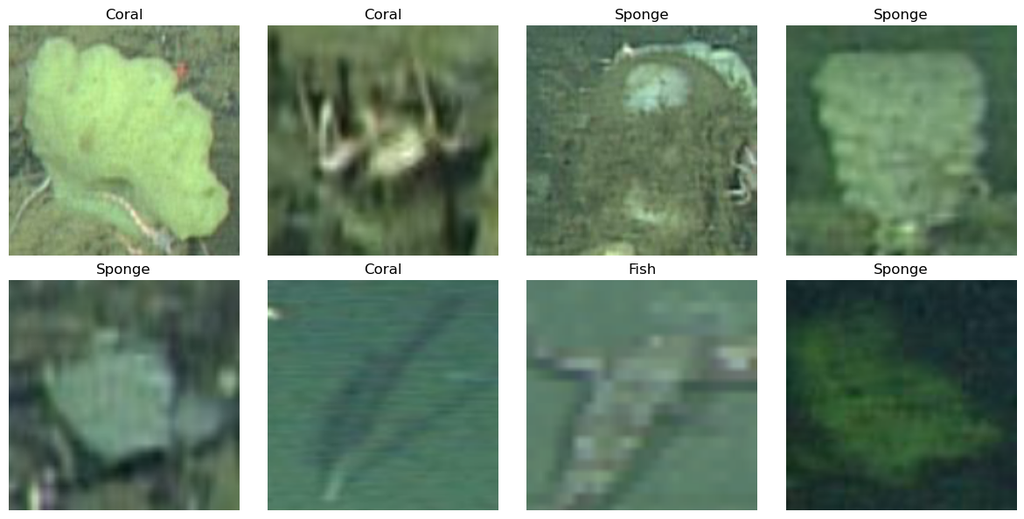

```python
import torch
import torch.nn as nn
import torch.optim as optim
import torchvision.models as models

# Create datasets
train_dataset = VMECroppedClassificationDataset("vme_dataset/train")
val_dataset = VMECroppedClassificationDataset("vme_dataset/val")
test_dataset = VMECroppedClassificationDataset("vme_dataset/test")

# Visualise samples from the training set
visualise_dataset(train_dataset)
```

#### 3.8 Analysis of Cropped Samples

Based on these marine organism images, we can deduce some challenges already:

1. **Image Quality Challenges**: The images are low resolution and blurry, which is a common issue with deep-sea imagery due to lighting limitations, water turbidity, and camera movement.
2. **Morphological Similarities**: There's considerable visual similarity between some corals and sponges, making classification difficult even for human experts. For example, the top-left coral and bottom-left sponge, have similar fan-like structures.
3. **Color Dominance**: The images display the characteristic green-blue color shift common in underwater photography, due to red wavelengths being quickly absorbed by water.
4. **Taxonomic Ambiguity**: Some organisms appear very ambiguous in their characteristics, highlighting a wide diversity within these taxonomic groups
5. **Scale Inconsistency**: The organisms appear at different scales and orientations, with no standardised frame of reference for size.

## 4 Transfer Learning for Marine Classification

In this section, we'll explore how transfer learning enables us to leverage pre-trained deep learning models for our marine imagery classification task.

### 4.1 Introduction to Transfer Learning

Transfer learning allows us to use knowledge gained from solving one problem and apply it to a different but related problem. In the context of deep neural networks, this means we can take a model that was pre-trained on a large dataset (like ImageNet with its millions of images) and adapt it to our specific VME classification task with relatively few examples.

There are several reasons to use transfer learning for our VME detector:

- **Limited Data**: We have only a few hundred examples of marine organisms, while training a deep CNN from scratch typically requires thousands or millions of examples.
- **Feature Reuse**: Lower-level features learned from ImageNet (edges, textures, basic shapes) are useful for many computer vision tasks, including marine organism identification.
- **Training Efficiency**: Starting with pretrained weights dramatically speeds up training and requires fewer epochs to reach good performance.

### 4.2 ResNet Architecture

For our VME detector, we're using the ResNet-18 architecture, a convolutional neural network with residual connections:

ResNet's key innovation is the use of residual connections (skip connections) that help overcome the vanishing gradient problem in deep networks. These connections allow the gradient to flow more easily through the network during backpropagation, enabling training of much deeper networks.

```python
import torchvision.models as models
import torch.nn as nn

# Create model
model = models.resnet18(weights=models.ResNet18_Weights.DEFAULT)

# Display architecture summary
print("ResNet-18 Architecture:")
for name, module in model.named_children():
    if isinstance(module, nn.Conv2d):
        print(f"{name}: Conv2d({module.in_channels}, {module.out_channels}, kernel_size={module.kernel_size})")
    elif isinstance(module, nn.Linear):
        print(f"{name}: Linear(in={module.in_features}, out={module.out_features})")
    else:
        print(f"{name}: {module}")
```

```
ResNet-18 Architecture:
conv1: Conv2d(3, 64, kernel_size=(7, 7))
bn1: BatchNorm2d(64, eps=1e-05, momentum=0.1, affine=True, track_running_stats=True)
relu: ReLU(inplace=True)
maxpool: MaxPool2d(kernel_size=3, stride=2, padding=1, dilation=1, ceil_mode=False)
layer1: Sequential(
  (0): BasicBlock(
    (conv1): Conv2d(64, 64, kernel_size=(3, 3), stride=(1, 1), padding=(1, 1), bias=False)
    (bn1): BatchNorm2d(64, eps=1e-05, momentum=0.1, affine=True, track_running_stats=True)
    (relu): ReLU(inplace=True)
    (conv2): Conv2d(64, 64, kernel_size=(3, 3), stride=(1, 1), padding=(1, 1), bias=False)
    (bn2): BatchNorm2d(64, eps=1e-05, momentum=0.1, affine=True, track_running_stats=True)
  )
  (1): BasicBlock(
    (conv1): Conv2d(64, 64, kernel_size=(3, 3), stride=(1, 1), padding=(1, 1), bias=False)
    (bn1): BatchNorm2d(64, eps=1e-05, momentum=0.1, affine=True, track_running_stats=True)
    (relu): ReLU(inplace=True)
    (conv2): Conv2d(64, 64, kernel_size=(3, 3), stride=(1, 1), padding=(1, 1), bias=False)
    (bn2): BatchNorm2d(64, eps=1e-05, momentum=0.1, affine=True, track_running_stats=True)
  )
)
layer2: Sequential(
  (0): BasicBlock(
    (conv1): Conv2d(64, 128, kernel_size=(3, 3), stride=(2, 2), padding=(1, 1), bias=False)
    (bn1): BatchNorm2d(128, eps=1e-05, momentum=0.1, affine=True, track_running_stats=True)
    (relu): ReLU(inplace=True)
    (conv2): Conv2d(128, 128, kernel_size=(3, 3), stride=(1, 1), padding=(1, 1), bias=False)
    (bn2): BatchNorm2d(128, eps=1e-05, momentum=0.1, affine=True, track_running_stats=True)
    (downsample): Sequential(
      (0): Conv2d(64, 128, kernel_size=(1, 1), stride=(2, 2), bias=False)
      (1): BatchNorm2d(128, eps=1e-05, momentum=0.1, affine=True, track_running_stats=True)
    )
  )
  (1): BasicBlock(
    (conv1): Conv2d(128, 128, kernel_size=(3, 3), stride=(1, 1), padding=(1, 1), bias=False)
    (bn1): BatchNorm2d(128, eps=1e-05, momentum=0.1, affine=True, track_running_stats=True)
    (relu): ReLU(inplace=True)
    (conv2): Conv2d(128, 128, kernel_size=(3, 3), stride=(1, 1), padding=(1, 1), bias=False)
    (bn2): BatchNorm2d(128, eps=1e-05, momentum=0.1, affine=True, track_running_stats=True)
  )
```

[output cut: 28 more lines]

```
    (downsample): Sequential(
      (0): Conv2d(256, 512, kernel_size=(1, 1), stride=(2, 2), bias=False)
      (1): BatchNorm2d(512, eps=1e-05, momentum=0.1, affine=True, track_running_stats=True)
    )
  )
  (1): BasicBlock(
    (conv1): Conv2d(512, 512, kernel_size=(3, 3), stride=(1, 1), padding=(1, 1), bias=False)
    (bn1): BatchNorm2d(512, eps=1e-05, momentum=0.1, affine=True, track_running_stats=True)
    (relu): ReLU(inplace=True)
    (conv2): Conv2d(512, 512, kernel_size=(3, 3), stride=(1, 1), padding=(1, 1), bias=False)
    (bn2): BatchNorm2d(512, eps=1e-05, momentum=0.1, affine=True, track_running_stats=True)
  )
)
avgpool: AdaptiveAvgPool2d(output_size=(1, 1))
fc: Linear(in=512, out=1000)
```

### 4.3 Model Adaptation for VME Detection

To adapt the pretrained ResNet-18 for our marine organism classification task, we need to replace the final fully connected layer

```python
model = models.resnet18(weights=models.ResNet18_Weights.DEFAULT)
num_ftrs = model.fc.in_features
model.fc = nn.Linear(num_ftrs, len(train_dataset.categories))
```

## 5. Model Training and Evaluation

### 5.1 Training Process

With our adapted ResNet model and prepared dataset, we can now train our VME detector. The training process involves:

1. **Forward pass**: Passing batches of images through the network to get predictions
2. **Loss calculation**: Computing the a loss between the predictions and ground truth
3. **Backward pass**: Calculating gradients via backpropagation
4. **Parameter update**: Adjusting model weights to minimise the loss

#### 5.1.1 Setting up the Data pipeline

Here we build our Dataloader objects which handles how data is fed into the model during training, validation and testing It serves as a bridge between our dataset and the actual model training. Below, we ensure to shuffle training data for better generalisation and create Validation and Testing Dataloader for Final model evaluation

```python
train_loader = DataLoader(train_dataset, batch_size=8, shuffle=True)
val_loader = DataLoader(val_dataset, batch_size=8)
test_loader = DataLoader(test_dataset, batch_size=8)
```

### 5.2 Training Loop

Now that we have a prepared dataset and adapted ResNet18 Model, we begin to train our VME indicator classifier. The training process involves multiple steps where the model is optimised for underwater imagery classification

```python
# Define loss function and optimizer
criterion = nn.CrossEntropyLoss()
optimizer = optim.Adam(model.parameters(), lr=0.001)

# Training function
def train_model(model, train_loader, val_loader, criterion, optimizer, num_epochs=5):
    device = torch.device("mps" if torch.cuda.is_available() else "cpu")
    model = model.to(device)

    history = {"train_loss": [], "val_loss": [], "train_acc": [], "val_acc": []}

    for epoch in range(num_epochs):
        model.train()
        running_loss = 0.0
        correct = 0
        total = 0

        for inputs, labels in train_loader:
            inputs, labels = inputs.to(device), labels.to(device)

            optimizer.zero_grad()

            # Forward pass
            outputs = model(inputs)
            loss = criterion(outputs, labels)

            # Backward pass and optimize
            loss.backward()
            optimizer.step()

            running_loss += loss.item() * inputs.size(0)
            _, predicted = torch.max(outputs, 1)
            total += labels.size(0)
            correct += (predicted == labels).sum().item()

        epoch_loss = running_loss / len(train_loader.dataset)
        epoch_acc = 100 * correct / total
        history["train_loss"].append(epoch_loss)
        history["train_acc"].append(epoch_acc)

        # Validation phase
        model.eval()
        running_loss = 0.0
        correct = 0
        total = 0

        with torch.no_grad():
            for inputs, labels in val_loader:
                inputs, labels = inputs.to(device), labels.to(device)

                # Forward pass
                outputs = model(inputs)
                loss = criterion(outputs, labels)

                running_loss += loss.item() * inputs.size(0)
                _, predicted = torch.max(outputs, 1)
                total += labels.size(0)
                correct += (predicted == labels).sum().item()

        val_loss = running_loss / len(val_loader.dataset)
        val_acc = 100 * correct / total
        history["val_loss"].append(val_loss)
        history["val_acc"].append(val_acc)

        print(f"Epoch {epoch+1}/{num_epochs}: "
              f"Train Loss: {epoch_loss:.4f}, Train Acc: {epoch_acc:.2f}%, "
              f"Val Loss: {val_loss:.4f}, Val Acc: {val_acc:.2f}%")

    return model, history

# Train the model
trained_model, history = train_model(model, train_loader, val_loader, criterion, optimizer)

# Save the model locally
torch.save(trained_model.state_dict(), "vme_classifier.pth")
```

```
Error loading image vme_dataset/train/coral/a333dafe-e532-421a-9dc7-e98f5c689243.png: image file is truncated
Error loading image vme_dataset/train/coral/a333dafe-e532-421a-9dc7-e98f5c689243.png: image file is truncated
Error loading image vme_dataset/train/coral/a333dafe-e532-421a-9dc7-e98f5c689243.png: image file is truncated
Error loading image vme_dataset/train/coral/a333dafe-e532-421a-9dc7-e98f5c689243.png: image file is truncated
Error loading image vme_dataset/train/coral/a333dafe-e532-421a-9dc7-e98f5c689243.png: image file is truncated
```

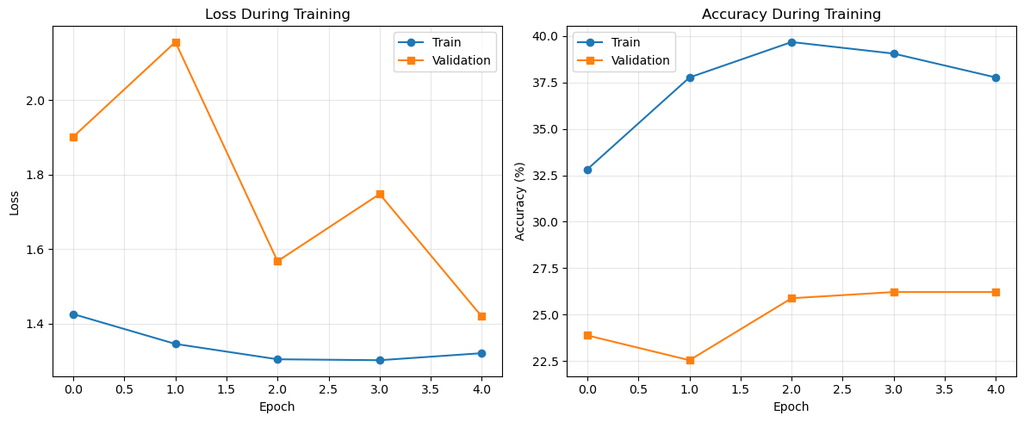

```python
plt.figure(figsize=(12, 5))

# Plot training and validation loss
plt.subplot(1, 2, 1)
plt.plot(history["train_loss"], label="Train", marker='o')
plt.plot(history["val_loss"], label="Validation", marker='s')
plt.title("Loss During Training")
plt.xlabel("Epoch")
plt.ylabel("Loss")
plt.legend()
plt.grid(alpha=0.3)

# Plot training and validation accuracy
plt.subplot(1, 2, 2)
plt.plot(history["train_acc"], label="Train", marker='o')
plt.plot(history["val_acc"], label="Validation", marker='s')
plt.title("Accuracy During Training")
plt.xlabel("Epoch")
plt.ylabel("Accuracy (%)")
plt.legend()
plt.grid(alpha=0.3)

plt.tight_layout()
plt.savefig("training_history.png", dpi=300)
plt.show()
```

### 5.3 Training Results Analysis

Let's analyse the training and validation curves to understand how our model learned: I will aim to keep this brief, because our model will be finetuned using hyperparameter optimisation

##### Loss and Accuracy Curves

1. Training-Validation gaps : The training accuracy significantly exceeds validation accuracy. This suggests **overfitting**. Where the model memorises training examples rather than learning generalisable patterns. This can be attributed to our limited dataset size and quality
2. Both training accuracy and loss begins to plateau around epoch 3, suggesting dimishing returns from additional training.

In order to achieve this visualisation, we used [Matplotlib](https://matplotlib.org/stable/), a powerful plotting library. Combined with (NumPy)[https://numpy.org/] for numerical calculations, we are able to create visualisations for our model's results for our analysis pipeline

## 6. Hyperparameter Tuning and Optimisation

### 6.1 Impact of Different Hyperparameters

For our context, we would like to adapt the ImageNet's features to underwater imagery while avoiding overfitting in our dataset.

```python
# Define two configurations with different learning rates
configs = [
    {
        'name': "Config A: Higher Learning Rate",
        'lr': 0.001,  # Higher learning rate
        'batch_size': 16
    },
    {
        'name': "Config B: Lower Learning Rate",
        'lr': 0.0001,  # Lower learning rate
        'batch_size': 16
    }
]
```

```python
import torch
import torch.nn as nn
import torch.optim as optim
import torchvision.models as models
from torch.utils.data import DataLoader
import matplotlib.pyplot as plt
import pandas as pd
import numpy as np
import time
import os

def finetune_marine_model(train_dataset, val_dataset):
    """
    Fine-tune the model with two different learning rate configurations
    """
    device = torch.device("mps" if torch.backends.mps.is_available() else
                          "cuda" if torch.cuda.is_available() else "cpu")
    print(f"Using device: {device}")

    results = []

    # Try each configuration
    for config_idx, config in enumerate(configs):
        print(f"\n=== Configuration {config_idx+1}/2: {config['name']} ===")

        # Create data loaders
        train_loader = DataLoader(
            train_dataset,
            batch_size=config['batch_size'],
            shuffle=True
        )

        val_loader = DataLoader(
            val_dataset,
            batch_size=config['batch_size']
        )

        # Create ResNet18 model with transfer learning
        model = models.resnet18(weights=models.ResNet18_Weights.DEFAULT)

        # Freeze all layers except the final layer for transfer learning
        for param in list(model.parameters())[:-2]:
            param.requires_grad = False

        # Modify final layer for our classification task
        num_ftrs = model.fc.in_features
        model.fc = nn.Linear(num_ftrs, len(train_dataset.categories))  # Adjust to match your number of classes

        model = model.to(device)

        criterion = nn.CrossEntropyLoss()
        optimizer = optim.Adam(model.parameters(), lr=config['lr'])

        # Train for just 3 epochs for demonstration
        epochs = 3
        history = {
            'train_loss': [], 'val_loss': [],
            'train_acc': [], 'val_acc': []
        }

        best_val_acc = 0
        start_time = time.time()

        for epoch in range(epochs):
            # Training phase
            model.train()
            train_loss = 0.0
            train_correct = 0
            train_total = 0

            for inputs, labels in train_loader:
                inputs, labels = inputs.to(device), labels.to(device)

                # Forward pass
                outputs = model(inputs)
                loss = criterion(outputs, labels)

                # Backward and optimize
                optimizer.zero_grad()
                loss.backward()
                optimizer.step()

                train_loss += loss.item() * inputs.size(0)
                _, predicted = torch.max(outputs, 1)
                train_total += labels.size(0)
                train_correct += (predicted == labels).sum().item()

            train_loss = train_loss / len(train_loader.dataset)
            train_acc = 100 * train_correct / train_total

            # Validation phase
            model.eval()
            val_loss = 0.0
            val_correct = 0
            val_total = 0

            with torch.no_grad():
                for inputs, labels in val_loader:
                    inputs, labels = inputs.to(device), labels.to(device)

                    outputs = model(inputs)
                    loss = criterion(outputs, labels)

                    val_loss += loss.item() * inputs.size(0)
                    _, predicted = torch.max(outputs, 1)
                    val_total += labels.size(0)
                    val_correct += (predicted == labels).sum().item()

            val_loss = val_loss / len(val_loader.dataset)
            val_acc = 100 * val_correct / val_total

            # Update history
            history['train_loss'].append(train_loss)
            history['val_loss'].append(val_loss)
            history['train_acc'].append(train_acc)
            history['val_acc'].append(val_acc)

            # Track best model
            if val_acc > best_val_acc:
                best_val_acc = val_acc
                # Save best model for this configuration
                torch.save(model.state_dict(), f"marine_model_config{config_idx+1}.pth")

            print(f"Epoch {epoch+1}/{epochs}: Train Acc: {train_acc:.2f}%, Val Acc: {val_acc:.2f}%")

        training_time = time.time() - start_time

        # Save results
        results.append({
            'config': config['name'],
            'lr': config['lr'],
            'best_val_acc': best_val_acc,
            'final_train_acc': history['train_acc'][-1],
            'final_val_acc': history['val_acc'][-1],
            'training_time': training_time,
            'history': history
        })

        print(f"Best validation accuracy: {best_val_acc:.2f}%")
        print(f"Training time: {training_time:.2f} seconds")


    return results
```